# PEC 3

Amelia Martínez Sequera, Sergio García Muñoz

20/5/2020

** Shiny app** Los datos y el archivo Rmd estan disponibles en: https://github.com/gititub/Shiny-app/tree/master/InsulinApp

El archivo Rmd de este documento y los datos que se han utilizado se encuentran en: https://github.com/gititub/Shiny-app

**Sección 1 (8 puntos)**

**(1) (0.5p)**

Hemos seleccionado el conjunto de datos titulado “Insulin Secretion of Asian Indians. Studying the relative contribution of Insulin Resistance & Secretion in Diabetes”. Está disponible en el sitio web de Kaggle, una comunidad online dedicada a la ciencia de datos y el machine learning. Los datos pueden consultarse o descargarse desde la dirección:

https://www.kaggle.com/jit1806/insulin-secretion-of-asian-indians

Podemos decir que los motivos que nos han llevado a escoger estos datos son:

- Son datos reales de una población concreta y bien definida. Pertenecen a voluntarios reclutados a partir de un programa de screening de salud “From Food to Nutrition” impulsado por la asociación sin ánimo de lucro SWANIRVAR, entre enero de 2017 y septiembre de 2018.
- La población es bastante numerosa, lo que esperamos facilite la obtención de resultados con una significación adecuada.
- Recogen una gran cantidad de variables, clínicas, bioquímicas y demográficas, por lo que pensamos que de ellos se puede extraer bastante información.

**(2) (0.5p)**

Se trata de un fichero de datos csv (comma separated values). Utilizamos un read.csv para importarlo como dataframe. Hay que añadir el parámetro skipNul=TRUE, ya que contiene embeded null characters.

```r
datosdf <- read_csv("~/R/PEC3_SAD/sage_tae_2019_df.csv", skipNul=TRUE)
```

[output not shown]

El fichero contiene 23 variables:

```r
head(datosdf)
```

|  | þÿ | AGE | SEX | BMI | WC | FBS..mmol.l. | TG | TC | SBP | DBP | DM_status | F.Ins.pmol.L. | Adiponectin.microgm.ml...5000.X. | Leptin..ng.ml. | HOMA2..B | HOMA2..S | HOMA2.IR | Body.Fat....from.Age..BMI | BMI_group | FBS | Ins | HOMA_IR | HOMA_B |
| --- | --- | --- | --- | --- | --- | --- | --- | --- | --- | --- | --- | --- | --- | --- | --- | --- | --- | --- | --- | --- | --- | --- | --- |
| 1 | 1 | 47 | M | 24.30194 | 101 | 4.290157 | 199.08320 | 145.9839 | NA | NA | Healthy | 33.28106 | NA | NA | 94.3 | 166.6 | 0.6002401 | 19.06290 | Lean | 77.22282 | 4.792089 | 0.9137250 | 121.29463 |
| 2 | 2 | 57 | F | 23.71338 | 81 | 4.761028 | 69.77708 | 183.5294 | NA | NA | Healthy | 29.64733 | NA | NA | 70.7 | 181.5 | 0.5509642 | 31.48007 | Lean | 85.69850 | 4.268874 | 0.9032991 | 67.70469 |
| 3 | 3 | 46 | M | 19.92188 | 79 | 5.287487 | 115.59184 | 214.7174 | NA | NA | Healthy | 22.01315 | 1.654843 | NA | 46.8 | 237.3 | 0.4214075 | 12.36281 | Lean | 95.17477 | 3.169640 | 0.7448636 | 35.46475 |
| 4 | 4 | 51 | M | 25.84312 | 95 | 4.842776 | 219.12716 | 207.6401 | NA | NA | Healthy | 33.58116 | NA | NA | 74.2 | 159.6 | 0.6265664 | 21.89468 | Obese | 87.16997 | 4.835300 | 1.0407233 | 72.01945 |
| 5 | 5 | 42 | M | 21.82657 | 89 | 5.117451 | 267.35322 | 213.3979 | NA | NA | Healthy | 62.79710 | NA | NA | 101.3 | 84.8 | 1.1792453 | 14.69986 | Lean | 92.11411 | 9.042058 | 2.0565462 | 111.80629 |
| 6 | 6 | 38 | F | 36.27000 | 115 | 5.982906 | 187.00000 | 230.0000 | NA | NA | Healthy | 115.68785 | 1.772031 | 168.78 | 113.5 | 45.0 | 2.2222222 | 47.84500 | Obese | 107.69231 | 16.657718 | 4.4294027 | 134.17921 |

```r
str(datosdf)
```

```
'data.frame':   650 obs. of  23 variables:
 $ þÿ                              : int  1 2 3 4 5 6 7 8 9 10 ...
 $ AGE                             : int  47 57 46 51 42 38 55 43 45 36 ...
 $ SEX                             : Factor w/ 2 levels "F","M": 2 1 2 2 2 1 1 1 2 1 ...
 $ BMI                             : num  24.3 23.7 19.9 25.8 21.8 ...
 $ WC                              : num  101 81 79 95 89 115 100 NA 86 129 ...
 $ FBS..mmol.l.                    : num  4.29 4.76 5.29 4.84 5.12 ...
 $ TG                              : num  199.1 69.8 115.6 219.1 267.4 ...
 $ TC                              : num  146 184 215 208 213 ...
 $ SBP                             : int  NA NA NA NA NA NA NA NA NA NA ...
 $ DBP                             : int  NA NA NA NA NA NA NA NA NA NA ...
 $ DM_status                       : Factor w/ 2 levels "Healthy","NDM": 1 1 1 1 1 1 1 2 1 1 ...
 $ F.Ins.pmol.L.                   : num  33.3 29.6 22 33.6 62.8 ...
 $ Adiponectin.microgm.ml...5000.X.: num  NA NA 1.65 NA NA ...
 $ Leptin..ng.ml.                  : num  NA NA NA NA NA ...
 $ HOMA2..B                        : num  94.3 70.7 46.8 74.2 101.3 ...
 $ HOMA2..S                        : num  166.6 181.5 237.3 159.6 84.8 ...
 $ HOMA2.IR                        : num  0.6 0.551 0.421 0.627 1.179 ...
 $ Body.Fat....from.Age..BMI       : num  19.1 31.5 12.4 21.9 14.7 ...
 $ BMI_group                       : Factor w/ 2 levels "Lean","Obese": 1 1 1 2 1 2 2 2 1 2 ...
 $ FBS                             : num  77.2 85.7 95.2 87.2 92.1 ...
 $ Ins                             : num  4.79 4.27 3.17 4.84 9.04 ...
 $ HOMA_IR                         : num  0.914 0.903 0.745 1.041 2.057 ...
 $ HOMA_B                          : num  121.3 67.7 35.5 72 111.8 ...
```

Como puede verse, hay 650 observaciones de 23 variables, la mayoría numéricas, habiendo tres que son factores y la primera que es un contador. A continuación hacemos una pequeña descripción de las mismas, así como su significado:

Variables demográficas y antropométricas:

**AGE**: Edad

**SEX**: Sexo

**BMI**: índice de masa corporal

**WC**: Perímetro abdominal

**Body.Fat….from.Age..BMI**: Porcentaje de grasa corporal calculado a partir de la edad y el BMI.

**BMI_group**: Factor categorizando el BMI

Variables bioquímicas y fisiológicas relacionadas con el perfil glucémico, lipídico y el riesgo cardiovascular:

**TG**: Triglicéridos (mg/dL)

**TC**: Colesterol total (mg/dL)

**SBP**: Presión arterial sistólica (mmHg)

**DBP**: Presión arterial diastólica (mmHg)

Variable que define el estado de presencia o ausencia de diabetes:

**DM_status**: Categórica con dos posibles valores: Healthy y NDM, entendido este último como diagnóstico de Diabetes tipo 2 reciente.

Variables relacionadas con el estado metabólico y la resistencia a la insulina:

**F.Ins.pmol.L**: Concentración plasmática en ayunas de insulina (pmol/L).

**Adiponectin.microgm.ml…5000.X**: Concentración de adiponectina (ug/mL). Se trata de una hormona secretada por los adipocitos, que participa en el metabolismo de la glucosa y los ácidos grasos.

**Leptin..ng.ml.**: Concentración de leptina (ng/mL). Se trata de una hormona, una adipoquina secretada mayoritariamente por los adipocitos y ejerce un feedback negativo sobre el hipotálamo para inhibir el apetito.

**HOMA2..B, HOMA2..S y HOMA2.IR**: Índices HOMA (Homeostaic Model Assessment). Se trata de índices calculados a partir de los niveles de insulina y glucosa que tratan de medir el grado de resistencia a la insulina. Se han calculado tres índices, el de función de células beta pancreáticas (HOMA-B), el de sensibilidad (HOMA-S) y el de resistencia a la insulina (HOMA-IR).

El resto de variables son iguales a otras ya descritas pero expresadas en unidades convencionales en lugar de unidades SI.

**(3) (1.5 p)**

**P1.** ¿Qué valores medios presentan las variables bioquímicas y fisiológicas según presencia de diabetes o no, categoría de índice de masa corporal y sexo? Presentar en formato tabla calculando sus intervalos de confianza.

Utilizamos la función tabular() contenida en el paquete tables, ya que permite de una manera sencilla crear tablas con selecciones de datos y aplicando funciones. Para hallar la media, creamos una función “Media” con el argumento na.rm=TRUE, para que no tenga en cuenta los valores NA presentes en algunos datos. Para calcular los intervalos de confianza creamos otra función “IC” que usa t.test para calcularlos y devuelve el resultado en forma de cadena de valores separados por un guión. Tanto a la función “Media” como a “IC” se les aplica un round para limitar el número de decimales. Por último, creamos la tabla con ayuda de la librería kableExtra y le damos formato.

```r
library(tables)
library(magrittr)
library(kableExtra)
attach(datosdf)
Media <- function(x){
  round(mean(x, na.rm=TRUE), 1)
  }
IC <- function(x){
 int<-c(t.test(x)$conf.int)
  result<-paste(round(int[1],1),round(int[2],1), sep="-")
  return(result)
}
biofis<- tabular ((DM_status*BMI_group*SEX) ~ (FBS+TG+TC+SBP+DBP)*(Media+IC))
biofis_kable<-toKable(biofis)
kable_styling(biofis_kable, full_width = TRUE, bootstrap_options="striped", row_label_position="c")
```

[output not shown]

**P2.** ¿Cuántos individuos hay que sean diabéticos y de sexo femenino, y que tengan una concentración de glucosa plasmática por encima de 200 mg/dL, y y qué porcentaje representan respecto al total de individuos de sexo femenino? ¿Y si ahora consideramos el sexo masculino? ¿Cuáles son las concentraciones mínima y máxima de glucosa en todos los pacientes? ¿Qué porcentaje de pacientes obesos tienen niveles de insulina elevados si consideramos un nivel de insulina elevado aquel que sea superior al percentil 95 de los individuos sanos?

Podemos hacer este tipo de consultas usando SQL. Para ello, cargamos las librerías sqldf y usamos SELECT con WHERE e IF. Es importante tener en cuenta que sqldf trabaja con dataframes y que cualquier variable que participe debe estar dentro del dataframe, o bien incorporarse como un dataframe en sí. Para responder a la última pregunta hemos tenido que convertir el percentil 95 de la concentración de insulina en personas sanas (In_S95) en un data frame, para poder incluirlo en el SELECT correspondiente que selecciona los valores de insulina en pacientes obesos por encima de este percentil.

```r
library(sqldf)
#Seleccionamos el sexo de los casos con glucosa>200, diabetes y sexo femenino, y usamos un nrow para contar el número de casos:
DM_SF<-nrow(sqldf("SELECT SEX FROM datosdf WHERE FBS>200 AND DM_status='NDM' AND SEX='F'"))
DM_SFp<-DM_SF/nrow(sqldf("SELECT FBS FROM datosdf WHERE SEX='F' AND DM_status='NDM'"))*100

paste("El número de mujeres diabéticas con glucosa > 200 mg/dL es:",DM_SF,"y representan un",round(DM_SFp, 1),"% del total de mujeres diabéticas")
```

```
[1] "El número de mujeres diabéticas con glucosa > 200 mg/dL es: 34 y representan un 33.7 % del total de mujeres diabéticas"
```

```r
#Hacemos lo mismo con el sexo masculino:
DM_SM<-nrow(sqldf("SELECT SEX FROM datosdf WHERE FBS>200 AND DM_status='NDM' AND SEX='M'"))
DM_SMp<-DM_SM/nrow(sqldf("SELECT FBS FROM datosdf WHERE SEX='M' AND DM_status='NDM'"))*100

paste("El número de hombres diabéticos con glucosa > 200 mg/dL es:",DM_SM,"y representan un",round(DM_SMp, 1),"% del total de hombres diabéticos")
```

```
[1] "El número de hombres diabéticos con glucosa > 200 mg/dL es: 26 y representan un 35.1 % del total de hombres diabéticos"
```

```r
paste("La concentración máxima de glucosa es:", round(max(FBS), 1), "mg/dL","y la mínima: ", round(min(FBS), 1), "mg/dL")
```

```
[1] "La concentración máxima de glucosa es: 379.1 mg/dL y la mínima:  66 mg/dL"
```

```r
#Seleccionamos niveles de insulina de sujetos sanos y calculamos el percentil 95. Posteriormente lo usamos para seleccionar los obsesos con niveles superiores a este percentil:
In_S<-sqldf("SELECT Ins FROM datosdf WHERE DM_status='Healthy'")
In_S95<-quantile(In_S[,1], probs = 0.95)
In_S95<-as.data.frame(In_S95)
In_Ob<-fn$sqldf("SELECT Ins FROM datosdf, In_S95 WHERE BMI_group='Obese' AND Ins > In_S95")
In_Obp<-nrow(In_Ob)/nrow(sqldf("SELECT Ins FROM datosdf WHERE BMI_group='Obese'"))*100

paste("El porcentaje de obesos con niveles de insulina superiores al percentil 95 de los niveles de pacientes sanos es:", round(In_Obp, 1),"%")
```

```
[1] "El porcentaje de obesos con niveles de insulina superiores al percentil 95 de los niveles de pacientes sanos es: 16.7 %"
```

**P3.** El síndrome metabólico se define como un conjunto de factores que conllevan un aumento del riesgo de padecer una enfermedad cardiovascular o diabetes mellitus tipo 2. La European Group for the Study of Insulin Resistance lo define mediante los siguientes criterios: 1. presencia del fenómeno de resistencia a la insulina (incremento del 25% de los valores de insulina en ayunas entre los individuos no-diabéticos) 2. Presencia de dos o más de los siguientes factores: - Obesidad central: diámetro de cintura ≥ 94 cm (en hombres), ≥ 80 cm (en mujeres). - Dislipidemia: TG ≥ 177 mg/dL y/o HDL-C < 1.0 mg/dL, o ser tratado por dislipidemia. - Hipertensión arterial: ≥ 140/90 mmHg o estar bajo tratamiento antihipertensivo - Hemoglobina glicosilada ≥ 6.1 mmol/L.

En base a los datos disponibles, cuántos individuos no serían diabéticos pero padecerían síndrome metabólico?

En primer lugar calculamos la insulina media de los sujetos sanos, después seleccionamos el grupo de interés (sanos, excluyendo diabéticos) mediante un SELECT. Por último creamos una función que nos permita evaluar este o cualquier otro grupo de pacientes, que contiene un IF con todas las condiciones del síndrome metabólico:

```r
#Calculamos la media de los valores de insulina entre los sujetos sanos:
In_Sm<-mean(In_S[,1])
#Seleccionamos los individuos sanos:
healthy<-sqldf("SELECT * FROM datosdf WHERE DM_Status='Healthy'")
healthy<-na.omit(healthy)
#Creamos la función que crea un dataframe con todos los datos de los casos que cumplen criterios de síndrome metabólico:
MS<-function(x) {
  res<-c()
  for(i in 1:nrow(x)){
        if(

(x$Ins[i]>1.25*In_Sm
& ((x$SEX[i]=="F" & x$WC[i]>=80) || (x$SEX[i]=="M" & x$WC[i]>=94))
& x$TG[i]>=177)||

(x$Ins[i]>1.25*In_Sm
& ((x$SEX[i]=="F" & x$WC[i]>=80) || (x$SEX[i]=="M" & x$WC[i]>=94))
& x$SBP[i]>=140 & x$DBP[i]>=90)||

(x$Ins[i]>1.25*In_Sm
& x$TG[i]>=177 & x$SBP[i]>=140 & x$DBP[i]>=90)

)
{res<-rbind(res, x[i,])}
}
  return(res)
}

Heal_MS<-MS(healthy)
paste("El número de individuos no diabéticos que padecen síndrome metabólico es de:", nrow(Heal_MS))
```

```
[1] "El número de individuos no diabéticos que padecen síndrome metabólico es de: 17"
```

**P4.** ¿Cuáles son los valores medios de las variables bioquímicas relacionadas con el metabolismo carbohidrato y lipídico, así como las relacionadas con la resistencia a la insulina en el grupo de pacientes diabéticos? ¿Y en los no diabéticos con síndrome metabólico? ¿Y en los sanos (no diabéticos y sin síndrome metabólico)? Acompañar las medias de sus correspondientes IC.

Nuevamente usamos SQL y después un loop para construir un dataframe con la media y el IC de aquellos casos que cumplen lascondiciones requeridas. Después construimos tablas con kable. Para el caso de los sanos hay que introducir un paso adicional, que ha consistido en crear un subset usando la condición de que NO se cumplan los criterios de síndrome metabólico:

```r
bioq_DM<- sqldf("SELECT FBS, TG, TC, Ins, HOMA_B, HOMA_IR, `HOMA2..B`, `HOMA2..S`, `HOMA2.IR`, `Adiponectin.microgm.ml...5000.X.`, `Leptin..ng.ml.` FROM datosdf WHERE DM_status=='NDM'")
bioq_DM_m<-c()
for(i in 1:ncol(bioq_DM)) {
    m<-Media(bioq_DM[,i])
    ic<-IC(bioq_DM[,i])
    bioq_DM_m<-cbind(bioq_DM_m, m, ic)
}
cnames<-c("Glucosa", "IC", "Triglicéridos", "IC", "Colesterol", "IC","Insulina", "IC", "HOMA_B", "IC", "HOMA_IR", "IC", "HOMA2_B", "IC", "HOMA2_S", "IC", "HOMA2_IR", "IC", "Adiponectina", "IC", "Leptina", "IC")
colnames(bioq_DM_m)<-cnames
kable(bioq_DM_m, align = "c", padding=5, format = "pandoc", caption = "Medias parámetros bioquímicos y de resistencia a insulina en individuos diabéticos")
```

Medias parámetros bioquímicos y de resistencia a insulina en individuos diabéticos

| Glucosa | IC | Triglicéridos | IC | Colesterol | IC | Insulina | IC | HOMA_B | IC | HOMA_IR | IC | HOMA2_B | IC | HOMA2_S | IC | HOMA2_IR | IC | Adiponectina | IC | Leptina | IC |
| --- | --- | --- | --- | --- | --- | --- | --- | --- | --- | --- | --- | --- | --- | --- | --- | --- | --- | --- | --- | --- | --- |
| 187.1 | 178.3-196 | 162.3 | 146.8-177.8 | 181.7 | 172.4-191 | 7.4 | 6.3-8.4 | 26.7 | 22.3-31.2 | 3.3 | 2.8-3.8 | 26.9 | 23.3-30.4 | 178.2 | 156.8-199.5 | 1.2 | 1-1.3 | 4.3 | 3.6-5 | 29.9 | 20.7-39 |

```r
bioq_HeMS<- sqldf("SELECT FBS, TG, TC, Ins, HOMA_B, HOMA_IR, `HOMA2..B`, `HOMA2..S`, `HOMA2.IR`, `Adiponectin.microgm.ml...5000.X.`, `Leptin..ng.ml.` FROM Heal_MS")
bioq_HeMS_m<-c()
for(i in 1:ncol(bioq_HeMS)) {
    m<-Media(bioq_HeMS[,i])
    ic<-IC(bioq_HeMS[,i])
    bioq_HeMS_m<-cbind(bioq_HeMS_m, m, ic)
}
cnames<-c("Glucosa", "IC", "Triglicéridos", "IC", "Colesterol", "IC","Insulina", "IC", "HOMA_B", "IC", "HOMA_IR", "IC", "HOMA2_B", "IC", "HOMA2_S", "IC", "HOMA2_IR", "IC", "Adiponectina", "IC", "Leptina", "IC")
colnames(bioq_HeMS_m)<-cnames
kable(bioq_HeMS_m, align = "c", padding=5, format = "pandoc", caption = "Medias parámetros bioquímicos y de resistencia a insulina en individuos no diabéticos con síndrome metabolico")
```

Medias parámetros bioquímicos y de resistencia a insulina en individuos no diabéticos con síndrome metabolico

| Glucosa | IC | Triglicéridos | IC | Colesterol | IC | Insulina | IC | HOMA_B | IC | HOMA_IR | IC | HOMA2_B | IC | HOMA2_S | IC | HOMA2_IR | IC | Adiponectina | IC | Leptina | IC |
| --- | --- | --- | --- | --- | --- | --- | --- | --- | --- | --- | --- | --- | --- | --- | --- | --- | --- | --- | --- | --- | --- |
| 92.9 | 87.3-98.5 | 169.3 | 121.7-216.9 | 166.4 | 149-183.8 | 8.6 | 7.5-9.8 | 117.7 | 90.3-145.2 | 2 | 1.7-2.3 | 99.3 | 85.5-113 | 93.8 | 82.9-104.7 | 1.1 | 1-1.3 | 4.1 | 2.7-5.5 | 45 | 25.7-64.4 |

```r
#Definimos un subset del dataframe healthy que contiene todos los individuos sin diabetes aplicando la condición de que NO cumplan lo requisitos para tener síndrome metabólico. Posteriormente continuamos como en los apartados anteriores:

Heal_NoMS<-subset.data.frame(healthy, subset =! (Ins>1.25*In_Sm
                       & ((SEX=="F" & WC>=80) || (SEX=="M" & WC>=94)& TG>=177)||
                                                  (Ins>1.25*In_Sm
               & ((SEX=="F" & WC>=80) || (SEX=="M" & WC>=94)) & SBP>=140 & DBP>=90)||
                                                 (Ins>1.25*In_Sm
                      & TG>=177 & SBP>=140 & DBP>=90)))

bioq_HeNoMS<- sqldf("SELECT FBS, TG, TC, Ins, HOMA_B, HOMA_IR, `HOMA2..B`, `HOMA2..S`, `HOMA2.IR`, `Adiponectin.microgm.ml...5000.X.`, `Leptin..ng.ml.` FROM Heal_NoMS")

bioq_HeNoMS_m<-c()
for(i in 1:ncol(bioq_HeNoMS)) {
    m<-Media(bioq_HeNoMS[,i])
    ic<-IC(bioq_HeNoMS[,i])
    bioq_HeNoMS_m<-cbind(bioq_HeNoMS_m, m, ic)
}
cnames<-c("Glucosa", "IC", "Triglicéridos", "IC", "Colesterol", "IC","Insulina", "IC", "HOMA_B", "IC", "HOMA_IR", "IC", "HOMA2_B", "IC", "HOMA2_S", "IC", "HOMA2_IR", "IC", "Adiponectina", "IC", "Leptina", "IC")
colnames(bioq_HeNoMS_m)<-cnames
kable(bioq_HeNoMS_m, align = "c", padding=5, format = "pandoc", caption = "Medias parámetros bioquímicos y de resistencia a insulina en individuos no diabéticos sin síndrome metabolico")
```

Medias parámetros bioquímicos y de resistencia a insulina en individuos no diabéticos sin síndrome metabolico

| Glucosa | IC | Triglicéridos | IC | Colesterol | IC | Insulina | IC | HOMA_B | IC | HOMA_IR | IC | HOMA2_B | IC | HOMA2_S | IC | HOMA2_IR | IC | Adiponectina | IC | Leptina | IC |
| --- | --- | --- | --- | --- | --- | --- | --- | --- | --- | --- | --- | --- | --- | --- | --- | --- | --- | --- | --- | --- | --- |
| 84.8 | 83.5-86.2 | 103.7 | 91.7-115.7 | 161.8 | 156.5-167 | 4.3 | 3.9-4.7 | 80.1 | 73.3-86.9 | 0.9 | 0.8-1 | 69.9 | 66.2-73.7 | 269.4 | 248.1-290.7 | 0.6 | 0.5-0.6 | 4 | 3.6-4.4 | 27.6 | 24-31.1 |

**P5.** ¿Cuáles son los valores medios de las variables bioquímicas relacionadas con el metabolismo carbohidrato y lipídico, así como las relacionadas con la resistencia a la insulina en el grupo de pacientes obesos y diabéticos? ¿Y en el de los obesos no diabéticos pero con síndrome metabólico? ¿Entre los individuos obesos del estudio, qué proporción son diabéticos, qué proporción tienen síndrome metabólico sin ser diabéticos y qué proporción son sanos? Acompañar las medias de sus correspondientes IC.

```r
# Operamos como en la pregunta 4 pero añadiendo la condición de que los sujetos sean obesos:
bioq_DM_Ob<- sqldf("SELECT FBS, TG, TC, Ins, HOMA_B, HOMA_IR, `HOMA2..B`, `HOMA2..S`, `HOMA2.IR`, `Adiponectin.microgm.ml...5000.X.`, `Leptin..ng.ml.` FROM datosdf WHERE DM_status=='NDM' AND BMI_group=='Obese'")
bioq_DM_Ob_m<-c()
for(i in 1:ncol(bioq_DM_Ob)) {
    m<-Media(bioq_DM_Ob[,i])
    ic<-IC(bioq_DM_Ob[,i])
    bioq_DM_Ob_m<-cbind(bioq_DM_Ob_m, m, ic)
}
cnames<-c("Glucosa", "IC", "Triglicéridos", "IC", "Colesterol", "IC","Insulina", "IC", "HOMA_B", "IC", "HOMA_IR", "IC", "HOMA2_B", "IC", "HOMA2_S", "IC", "HOMA2_IR", "IC", "Adiponectina", "IC", "Leptina", "IC")
colnames(bioq_DM_Ob_m)<-cnames
kable(bioq_DM_Ob_m, align = "c", padding=5, format = "pandoc", caption = "Medias parámetros bioquímicos y de resistencia a insulina en individuos obesos y diabéticos")
```

Medias parámetros bioquímicos y de resistencia a insulina en individuos obesos y diabéticos

| Glucosa | IC | Triglicéridos | IC | Colesterol | IC | Insulina | IC | HOMA_B | IC | HOMA_IR | IC | HOMA2_B | IC | HOMA2_S | IC | HOMA2_IR | IC | Adiponectina | IC | Leptina | IC |
| --- | --- | --- | --- | --- | --- | --- | --- | --- | --- | --- | --- | --- | --- | --- | --- | --- | --- | --- | --- | --- | --- |
| 176.9 | 165.3-188.5 | 154.6 | 137.8-171.5 | 185.8 | 170.3-201.4 | 9.3 | 7.7-10.9 | 36.2 | 28.7-43.7 | 4 | 3.3-4.7 | 34.9 | 29-40.8 | 138.3 | 109.4-167.2 | 1.4 | 1.2-1.6 | 4.7 | 3.6-5.8 | 58 | 37.2-78.9 |

```r
#Para seleccionar pacientes no diabéticos con síndrome metabólico y obesos podemos usar el dataframe donde están recogidos todos los que tienen síndrome metabólico y seleccionar por BMI_group:
bioq_nDM_MS_Ob<- sqldf("SELECT FBS, TG, TC, Ins, HOMA_B, HOMA_IR, `HOMA2..B`, `HOMA2..S`, `HOMA2.IR`, `Adiponectin.microgm.ml...5000.X.`, `Leptin..ng.ml.` FROM Heal_MS WHERE BMI_group=='Obese'")
#Aplicamos un loop para calcular las medias e IC a cada varaible de la selección:
bioq_nDM_MS_Ob_m<-c()
for(i in 1:ncol(bioq_nDM_MS_Ob)) {
    m<-Media(bioq_nDM_MS_Ob[,i])
    ic<-IC(bioq_nDM_MS_Ob[,i])
    bioq_nDM_MS_Ob_m<-cbind(bioq_nDM_MS_Ob_m, m, ic)
}
cnames<-c("Glucosa", "IC", "Triglicéridos", "IC", "Colesterol", "IC","Insulina", "IC", "HOMA_B", "IC", "HOMA_IR", "IC", "HOMA2_B", "IC", "HOMA2_S", "IC", "HOMA2_IR", "IC", "Adiponectina", "IC", "Leptina", "IC")
colnames(bioq_nDM_MS_Ob_m)<-cnames
kable(bioq_nDM_MS_Ob_m, align = "c", padding=5, format = "pandoc", caption = "Medias parámetros bioquímicos y de resistencia a insulina en individuos obesos, NO diabéticos, CON síndrome metabólico")
```

Medias parámetros bioquímicos y de resistencia a insulina en individuos obesos, NO diabéticos, CON síndrome metabólico

| Glucosa | IC | Triglicéridos | IC | Colesterol | IC | Insulina | IC | HOMA_B | IC | HOMA_IR | IC | HOMA2_B | IC | HOMA2_S | IC | HOMA2_IR | IC | Adiponectina | IC | Leptina | IC |
| --- | --- | --- | --- | --- | --- | --- | --- | --- | --- | --- | --- | --- | --- | --- | --- | --- | --- | --- | --- | --- | --- |
| 96.9 | 87.2-106.7 | 126.7 | 71.7-181.7 | 150.1 | 126.9-173.3 | 8.1 | 6.4-9.9 | 96.8 | 60.6-133 | 2 | 1.4-2.5 | 87.3 | 68.6-106 | 97.8 | 80.6-115.1 | 1.1 | 0.8-1.3 | 2.9 | 0.6-5.1 | 52.9 | 14.1-91.7 |

```r
#Para conocer la proporción de individuos obesos que tienen diabetes, los que tienen síndrome metabólico y los que son sanos, calculamos el número de obesos total y el de obesos diabéticos en datosdf, el número de obesos no diabéticos pero con síndrome metabólico en Heal_MS, y el de obesos sanos Heal_NoMS. Para ello hacemos subsets con las condiciones de interés y contamos filas. Hay que tener en cuenta que los porcentajes no sumarán 100 debido a los casos en los que no se ha podido determinar la presencia de síndrome metabólico por falta de datos.

pOb_SM<-nrow(subset.data.frame(Heal_MS, subset = (BMI_group=='Obese'))) / nrow(subset.data.frame(datosdf, subset = (BMI_group=='Obese')))*100
pOb_DM<-nrow(subset.data.frame(datosdf, subset = (BMI_group=='Obese' & DM_status=='NDM'))) / nrow(subset.data.frame(datosdf, subset = (BMI_group=='Obese')))*100
pOb_H<-nrow(subset.data.frame(Heal_NoMS, subset = (BMI_group=='Obese'))) / nrow(subset.data.frame(datosdf, subset = (BMI_group=='Obese')))*100

paste("Entre los individuos obesos, son diabéticos el",round(pOb_DM, 1),"%.")
```

```
[1] "Entre los individuos obesos, son diabéticos el 31.4 %."
```

```r
paste("Entre los individuos obesos, tienen síndrome metabólico el",round(pOb_SM, 1),"%.")
```

```
[1] "Entre los individuos obesos, tienen síndrome metabólico el 3.3 %."
```

```r
paste("Entre los individuos obesos, son sanos el",round(pOb_H, 1),"%.")
```

```
[1] "Entre los individuos obesos, son sanos el 24.5 %."
```

**P6.** El estándar de oro para medir la sensibilidad a la insulina corporal total se denomina clamp hiperinsulinémico-euglucémico, pero se trata de un procedimiento complejo y no se usa en la práctica. En su lugar se emplea el índice HOMA-IR. Se suele emplear un valor de 2,6 como punto de corte para diagnosticar la resistencia a la insulina, resultando útil, sobre todo, para evaluar dicha resistencia en pacientes con normoglucemia. Posteriormente, un modelo actualizado (HOMA2) añadió los efectos de la resistencia a la glucosa hepática y periférica, las variaciones que se producen en la secreción de insulina a concentraciones de glucosa elevadas, así como la contribución de la proinsulina circulante. ¿Cuáles son los valores medios y sus IC de HOMA-IR y HOMA2_IR en cada uno de los siguientes grupos?:

- No diabéticos, no obesos
- No diabéticos, obesos
- Diabéticos, no obesos
- Diabéticos, obesos

```r
# Hacemos uso nuevamente de tabular y toKable:
homa_ir<- tabular ((DM_status*BMI_group) ~ (HOMA_IR+HOMA2.IR)*(Media+IC))
homa_ir_kable<-toKable(homa_ir)
kable_styling(homa_ir_kable, full_width = TRUE, bootstrap_options="striped", row_label_position="c")
```

[output not shown]

**(4) (1.5p)**

Para el resumen paramétrico usamos un summary:

```r
summary(datosdf)
```

```
       þÿ             AGE         SEX          BMI              WC
 Min.   :  1.0   Min.   : 16.00   F:417   Min.   :13.22   Min.   : 54.00
 1st Qu.:163.2   1st Qu.: 35.00   M:233   1st Qu.:20.78   1st Qu.: 78.00
 Median :325.5   Median : 44.00           Median :23.81   Median : 86.00
 Mean   :325.5   Mean   : 44.33           Mean   :24.36   Mean   : 85.91
 3rd Qu.:487.8   3rd Qu.: 53.00           3rd Qu.:26.57   3rd Qu.: 94.00
 Max.   :650.0   Max.   :104.00           Max.   :52.50   Max.   :143.00
                 NA's   :1                                NA's   :91
  FBS..mmol.l.          TG                TC              SBP             DBP
 Min.   : 3.665   Min.   :  17.58   Min.   : 53.09   Min.   : 83.0   Min.   : 29.00
 1st Qu.: 4.578   1st Qu.:  70.69   1st Qu.:130.80   1st Qu.:111.0   1st Qu.: 71.00
 Median : 5.225   Median : 105.04   Median :162.11   Median :124.0   Median : 80.00
 Mean   : 6.441   Mean   : 126.64   Mean   :166.57   Mean   :127.6   Mean   : 79.98
 3rd Qu.: 7.159   3rd Qu.: 159.00   3rd Qu.:193.46   3rd Qu.:139.0   3rd Qu.: 88.00
 Max.   :21.062   Max.   :1084.24   Max.   :381.06   Max.   :198.0   Max.   :121.00
                  NA's   :73        NA's   :74       NA's   :193     NA's   :211
   DM_status   F.Ins.pmol.L.     Adiponectin.microgm.ml...5000.X. Leptin..ng.ml.
 Healthy:475   Min.   :  7.091   Min.   : 0.00274                 Min.   :  1.558
 NDM    :175   1st Qu.: 16.285   1st Qu.: 1.71082                 1st Qu.:  7.412
               Median : 26.642   Median : 3.40912                 Median : 16.770
               Mean   : 38.723   Mean   : 3.89672                 Mean   : 28.011
               3rd Qu.: 49.302   3rd Qu.: 5.67910                 3rd Qu.: 36.532
               Max.   :251.722   Max.   :12.32316                 Max.   :207.100
                                 NA's   :274                      NA's   :219
    HOMA2..B         HOMA2..S        HOMA2.IR      Body.Fat....from.Age..BMI BMI_group
 Min.   :  1.70   Min.   : 13.2   Min.   :0.1260   Min.   : 4.093            Lean :405
 1st Qu.: 31.40   1st Qu.:105.0   1st Qu.:0.3186   1st Qu.:21.421            Obese:245
 Median : 53.00   Median :187.6   Median :0.5331   Median :27.890
 Mean   : 57.36   Mean   :228.0   Mean   :0.7808   Mean   :28.044
 3rd Qu.: 79.60   3rd Qu.:313.9   3rd Qu.:0.9526   3rd Qu.:33.375
 Max.   :168.30   Max.   :793.6   Max.   :7.5758   Max.   :71.180

      FBS              Ins            HOMA_IR            HOMA_B
 Min.   : 65.97   Min.   : 1.021   Min.   : 0.1804   Min.   :  1.509
 1st Qu.: 82.41   1st Qu.: 2.345   1st Qu.: 0.5664   1st Qu.: 22.407
 Median : 94.05   Median : 3.836   Median : 0.9713   Median : 49.166
 Mean   :115.94   Mean   : 5.576   Mean   : 1.7164   Mean   : 62.917
 3rd Qu.:128.87   3rd Qu.: 7.099   3rd Qu.: 1.9248   3rd Qu.: 89.232
 Max.   :379.11   Max.   :36.245   Max.   :18.6231   Max.   :233.724
```

Representamos histogramas de frecuencias de variables que nos puede interesar conocer cómo se distribuyen. La función hist.dataframe del paquete Hmisc hace histogramas con todas las variables del dataframe

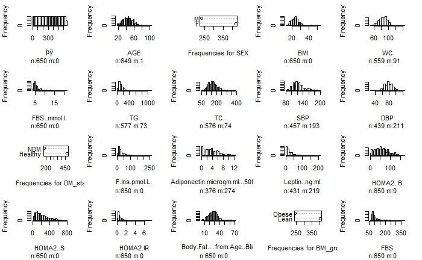

```
click left mouse button to proceed
```

```r
library(Hmisc)
hist.data.frame(datosdf)
```

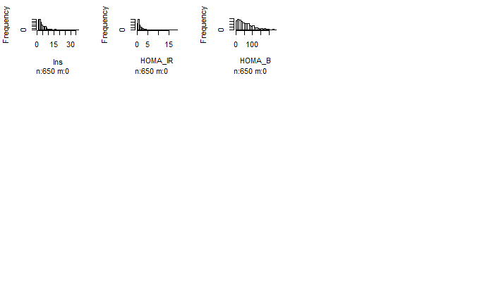

```r
#A partir de la anterior, seleccionamos algunas variables que puedan interesar más:
par(mfrow=c(3,3))
```

```r
hist(FBS, main="Glucosa plasmática", breaks=50, col="cadetblue1")
hist(TG, main="Triglicéridos", breaks=50, col="cadetblue2")
```

```r
hist(TC, main="Colesterol total", breaks=50, col="cadetblue3")
hist(Ins, main = "Insulina", breaks=50, col="olivedrab1")
```

[figure not shown]

```r
hist(Adiponectin.microgm.ml...5000.X., main = "Adiponectina", breaks=50, col="olivedrab2")
hist(Leptin..ng.ml., main = "Leptina", breaks=50, col="olivedrab3")
```

Representamos diagramas de cajas que ayuden a visualizar gráficamente las tablas de medias que hemos construido en los apartados anteriores. Usamos ggplot2 con un facet_grid, que es muy útil para dividir por variables los gráficos de manera sencilla:

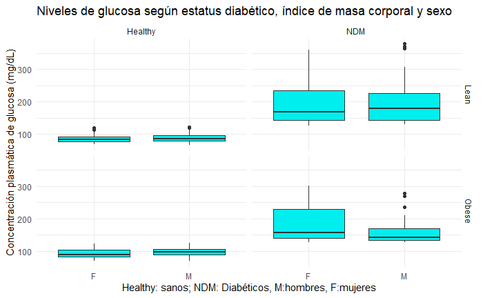

```r
library(ggplot2)
library(dplyr)
library(tidyr)
#Boxplots glucosa plasmática según estatus diabético, índice de masa corporal y sexo
box_FBS<-ggplot(datosdf, aes(x=SEX, y=FBS))+
  geom_boxplot(fill="cyan2")+
  facet_grid(BMI_group~DM_status)+
  labs(title ="Niveles de glucosa según estatus diabético, índice de masa corporal y sexo", x = "Healthy: sanos; NDM: Diabéticos, M:hombres, F:mujeres", y = "Concentración plasmática de glucosa (mg/dL)")+
  theme_minimal()
box_FBS
```

Representamos gráficos con 3 variables usando levelplot, una función incluída en el paquete lattice. Construye gráficos de niveles en un diagrama 2D en el que la tercera varaibles se representa mediante una escala de colores. Para poder añadir una leyenda a la escala de colores es necesario usar una función adicional, trellis.focus. Usamos estas representaciones para visualizar niveles de insulina en según el estado diabético y las distintas variables asociadas a adiposidad (WC, BMI, leptina y adiponectina):

```r
#Levelplot multivariable: Insulinemia según distintas combinaciones de parámetros de adiposidad, para diabéticos y no diabéticos).
library(lattice)
library(colorspace)
levelplot(Ins~WC*Adiponectin.microgm.ml...5000.X.|DM_status, data=datosdf, cuts = 80, col.regions = sequential_hcl(100, rev = T),
form="fit", xlab = "Perímetro de cintura (cm)", ylab = "Adiponectina (ng/mL)", main=" Insulinemia según perímetro de cintura y adiponectina")
trellis.focus("legend", side="right", clipp.off=TRUE, highlight=FALSE)
```

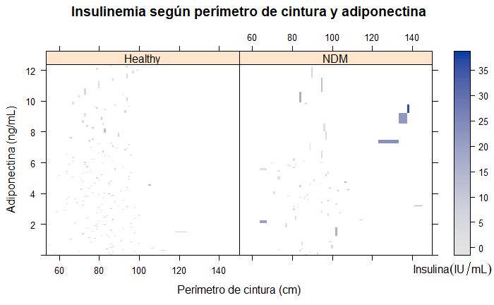

```r
grid::grid.text(expression(Insulina (IU/mL)), 0.2, 0, hjust=0.6, vjust=1.5)
```

```r
levelplot(Ins~Leptin..ng.ml.*Adiponectin.microgm.ml...5000.X.|DM_status, data=datosdf, cuts = 80, col.regions = sequential_hcl(100, rev = T),
form="fit", xlab = "Leptina (ng/mL)", ylab = "Adiponectina (ng/mL)", main="Insulinemia según concentraciones de leptina y adiponectina")
trellis.focus("legend", side="right", clipp.off=TRUE, highlight=FALSE)
```

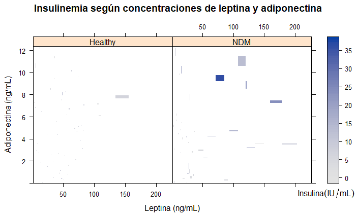

```r
grid::grid.text(expression(Insulina (IU/mL)), 0.2, 0, hjust=0.6, vjust=1.5)
```

```r
levelplot(Ins~Leptin..ng.ml.*BMI|DM_status, data=datosdf, cuts = 80, col.regions = sequential_hcl(100, rev = T),
form="fit", xlab = "Leptina (ng/mL)", ylab = "Índice de masa corporal", main="Insulinemia según índice de masa corporal y adiponectina")
trellis.focus("legend", side="right", clipp.off=TRUE, highlight=FALSE)
```

[figure not shown]

```r
grid::grid.text(expression(Insulina (IU/mL)), 0.2, 0, hjust=0.6, vjust=1.5)
```

```r
#Podemos afinar más si usamos un subset como el de los datos bioquímicos de los individuos diabéticos y obesos. Representamos en este caso la resistencia a insulina (índice HOMA.IR) según niveles de leptina y adiponectina, pero dentro del grupo de los obesos con diabetes:

levelplot(HOMA2.IR~Leptin..ng.ml.*Adiponectin.microgm.ml...5000.X., data=bioq_DM_Ob, cuts = 80, col.regions = sequential_hcl(100, rev = T),
form="fit", xlab = "Leptina (ng/mL)", ylab = "Adiponectina (ng/mL)", main="HOMA.IR según leptina y adiponectina en diabéticos obesos")
trellis.focus("legend", side="right", clipp.off=TRUE, highlight=FALSE)
```

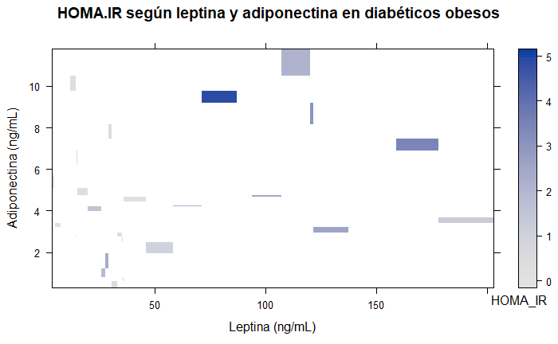

```r
grid::grid.text(expression(HOMA_IR), 0.2, 0, hjust=0.6, vjust=1.5)
```

```r
#Y compararlo con los obesos no diabéticos pero con síndrome metabólico:

levelplot(HOMA_IR~Leptin..ng.ml.*Adiponectin.microgm.ml...5000.X., data=bioq_nDM_MS_Ob, cuts = 80, col.regions = sequential_hcl(100, rev = T),
form="fit", xlab = "Leptina (ng/mL)", ylab = "Adiponectina (ng/mL)", main="HOMA.IR según leptina y adiponectina en no diabético obesos con s. metabólico")
trellis.focus("legend", side="right", clipp.off=TRUE, highlight=FALSE)
```

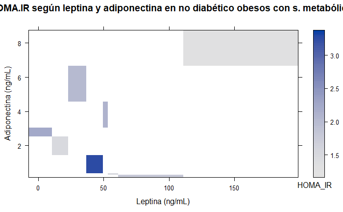

```r
grid::grid.text(expression(HOMA_IR), 0.2, 0, hjust=0.6, vjust=1.5)
trellis.unfocus()
```

**Estructura de los datos**

```r
str(datosdf)
```

```
'data.frame':   650 obs. of  23 variables:
 $ þÿ                              : int  1 2 3 4 5 6 7 8 9 10 ...
 $ AGE                             : int  47 57 46 51 42 38 55 43 45 36 ...
 $ SEX                             : Factor w/ 2 levels "F","M": 2 1 2 2 2 1 1 1 2 1 ...
 $ BMI                             : num  24.3 23.7 19.9 25.8 21.8 ...
 $ WC                              : num  101 81 79 95 89 115 100 NA 86 129 ...
 $ FBS..mmol.l.                    : num  4.29 4.76 5.29 4.84 5.12 ...
 $ TG                              : num  199.1 69.8 115.6 219.1 267.4 ...
 $ TC                              : num  146 184 215 208 213 ...
 $ SBP                             : int  NA NA NA NA NA NA NA NA NA NA ...
 $ DBP                             : int  NA NA NA NA NA NA NA NA NA NA ...
 $ DM_status                       : Factor w/ 2 levels "Healthy","NDM": 1 1 1 1 1 1 1 2 1 1 ...
 $ F.Ins.pmol.L.                   : num  33.3 29.6 22 33.6 62.8 ...
 $ Adiponectin.microgm.ml...5000.X.: num  NA NA 1.65 NA NA ...
 $ Leptin..ng.ml.                  : num  NA NA NA NA NA ...
 $ HOMA2..B                        : num  94.3 70.7 46.8 74.2 101.3 ...
 $ HOMA2..S                        : num  166.6 181.5 237.3 159.6 84.8 ...
 $ HOMA2.IR                        : num  0.6 0.551 0.421 0.627 1.179 ...
 $ Body.Fat....from.Age..BMI       : num  19.1 31.5 12.4 21.9 14.7 ...
 $ BMI_group                       : Factor w/ 2 levels "Lean","Obese": 1 1 1 2 1 2 2 2 1 2 ...
 $ FBS                             : num  77.2 85.7 95.2 87.2 92.1 ...
 $ Ins                             : num  4.79 4.27 3.17 4.84 9.04 ...
 $ HOMA_IR                         : num  0.914 0.903 0.745 1.041 2.057 ...
 $ HOMA_B                          : num  121.3 67.7 35.5 72 111.8 ...
```

**Valores NA.**

```r
table(is.na(datosdf$AGE))
```

```
FALSE  TRUE
  649     1
```

```r
datosdf2 =na.omit(datosdf)
table(is.na(datosdf2))
```

```
FALSE
 5819
```

**(5) PROBABILIDAD**

**Distribución normal.**

Tomamos como variable aleatoria la concentración de azúcar en sangre en ayunas, para dos grupos: enfermos o sanos. Suponemos que estos valores siguen una distribución normal en ambos grupos: SANOS: N(4.7, 0.57) DM2: N(11.4,3.9)

```r
FBSH<- subset(datosdf2$FBS..mmol.l., datosdf2$DM_status=="Healthy")
FBSDM <- subset(datosdf2$FBS..mmol.l., datosdf2$DM_status=="NDM")
mean(FBSH); sd(FBSH); mean(FBSDM); sd(FBSDM)
```

```
[1] 4.713599
[1] 0.5677863
[1] 11.42383
[1] 3.918924
```

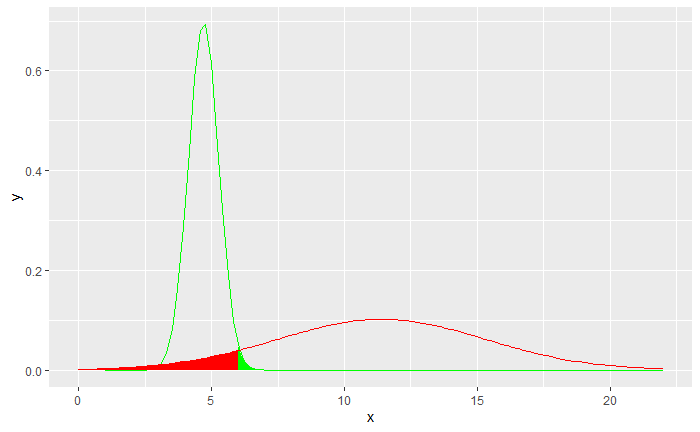

```r
library(ggplot2)
ggplot(data.frame(x = c(1, 22)), aes(x)) +
  stat_function(fun = dnorm, args = list(mean = 4.7, sd = 0.57), col='green') +
  stat_function(fun = dnorm, args = list(mean =4.7, sd =.57), xlim = c(6,7),
                geom = "area", fill = "green")+
  stat_function(fun = dnorm, args = list(mean = 11.4, sd = 3.9), col='red') +
  stat_function(fun = dnorm, args = list(mean= 11.4, sd =3.9), xlim = c(0,6),
                geom = "area", fill = "red")
```

**P1.**Se considera que los individuos con valores de azúcar en sangre por encima de 7 serían clasificados como DM2. ¿qué porcentaje de la población se consideraría incorrectamente sana?

```r
library(fastGraph)
P1<- pnorm(7,mean=11.4,sd=3.9, lower.tail = T)
cat("la probabilidad de ser clasificado incorrectamente sano es:", P1)
```

```
la probabilidad de ser clasificado incorrectamente sano es: 0.1296166
```

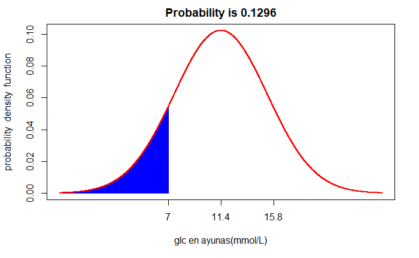

```r
shadeDist(7,"dnorm",11.4, 3.9,lower.tail = T, col=c("red", "blue"), xlab="glc en ayunas(mmol/L)")
```

**P2** ¿qué porcentaje se clasificaría como enfermo pero está realmente sano?

```r
P2<- pnorm(7, mean=4.7, sd=0.57, lower.tail = F)
cat("la probabilidad de ser clasificado erróneamente como DM2 es:", P2)
```

```
la probabilidad de ser clasificado erróneamente como DM2 es: 2.729095e-05
```

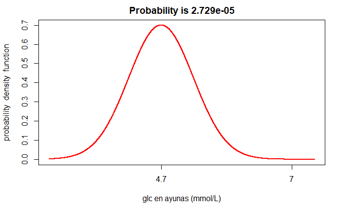

```r
shadeDist(7, "dnorm", 4.7, 0.57, lower.tail = F, col=c("red","blue"), xlab="glc en ayunas (mmol/L)")
```

**P3.** ¿Cuál es la probabilidad en el grupo de individuos con DM2 que se obtengan concentraciones entre 10 y 13?

```r
pnorm(c(13,10), mean = 11.4, sd=3.9)
```

```
[1] 0.6591911 0.3598071
```

```r
cat("la probabilidad de obtener concentraciones entre 10 y 13 en DM2 es: ", 0.6592-0.3598)
```

```
la probabilidad de obtener concentraciones entre 10 y 13 en DM2 es:  0.2994
```

**P4.** Determinar la concentración mínima del 30% de los individuos sanos con más concentración.

```r
qnorm(0.3, mean=4.7, sd=0.57)
```

```
[1] 4.401092
```

**Binomial.**

**P5.** Si la probabilidad de tener DM2 es de un 8%, ¿que probabilidad hay de que si vienen 16 voluntarios a hacerse la analítica sean todos diabéticos? Se trataria entonces de una distribución binomial: n = 16 y p = 0.08. (X → B (16, 0.08))

```r
td<- dbinom(16,16,0.08)
cat("P[X=16]=",td)
```

```
P[X=16]= 2.81475e-18
```

Es prácticamente 0.

**P6.** ¿y de que más de la mitad lo sean?

```r
md<- pbinom(8,16,0.08)
cat("P[Sean diabéticos tipo 2 más de la mitad] = P[X > 8] = 1 – P[X =< 8] = 1 – F(8)=", 1-md)
```

```
P[Sean diabéticos tipo 2 más de la mitad] = P[X > 8] = 1 – P[X =< 8] = 1 – F(8)= 9.112486e-07
```

También es muy poco probable.

**P7.** Y que ninguno sea diabético tipo 2?

```r
nd<- dbinom(0,16,0.08)
cat("P[ninguno sea diabético 2] = P[X = 0]=", nd)
```

```
P[ninguno sea diabético 2] = P[X = 0]= 0.2633936
```

**P8.** ¿Y la probabilidad de que, al menos, 2 sean diabéticos tipo2?

```r
dd<- 1-pbinom(1,16,0.08)
cat("P[por lo menos dos sean diabéticos] = P[X >= 2] = 1 – P[X < 2] = 1 – F(1)=", dd)
```

```
P[por lo menos dos sean diabéticos] = P[X >= 2] = 1 – P[X < 2] = 1 – F(1)= 0.3701457
```

**P10.** Estimar la media de la muestra con su intervalo de confianza al 95%.

```r
set.seed(2027)
muestra<- rnorm(400, mean=4.7, sd=0.57)
media40<- mean(muestra)
sd40<- sd(muestra)
se40<- sd40/sqrt(length(muestra))
li40<- media40-qt(.975, length(muestra)-1)*se40
ls40<- media40+qt(.975, length(muestra)-1)*se40
cat("el intervalo de confianza es:",li40, ls40)
```

```
el intervalo de confianza es: 4.647513 4.757533
```

También se puede calcular con un t-test:

```r
t.test(muestra, conf.level = 0.95)
```

```
    One Sample t-test

data:  muestra
t = 168.06, df = 399, p-value < 2.2e-16
alternative hypothesis: true mean is not equal to 0
95 percent confidence interval:
 4.647513 4.757533
sample estimates:
mean of x
 4.702523
```

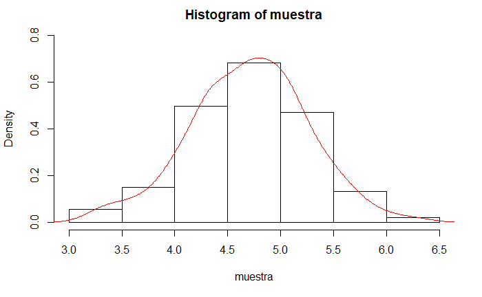

```r
hist(muestra,ylim=c(0,0.8), freq = F)
lines(density(muestra), col="red")
```

**(6) REGRESIÓN LINEAL**

HOMA IR= (insul.en sangre en ayuno x glucosa en sangre en ayuno)/22.5

HOMA B= 20X insul. en sangre en ayuno x /(gluc. en ayuno-3.5)

Los no obesos son individuos con IMC <25(La OMS define a un adulto que tenga un BMI entre 25 y 29,9 como exceso de peso - adulto que tenga un BMI de 30 o más alto se considera obeso - un BMI abajo de 18,5 se considere peso insuficiente, y entre 18,5 a 24,9 al peso sano).

**Normalidad de las variables:**

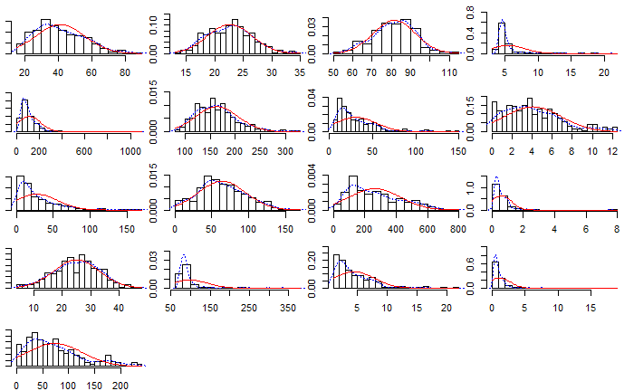

```r
multi.hist(x = datosdf2[,c(2,4,5,6,7,8,12,13,14,15,16,17,18,20,21,22,23)], dcol = c("blue","red"), dlty = c("dotted", "solid"),
           main = "")
```

| Test | H | p value | MVN |
| --- | --- | --- | --- |
| Royston | 554.683 | 1.418198e-112 | NO |

|  | Test | Variable | Statistic | p value | Normality |
| --- | --- | --- | --- | --- | --- |
| 1 | Shapiro-Wilk | AGE | 0.9656 | <0.001 | NO |
| 2 | Shapiro-Wilk | BMI | 0.9918 | 0.1732 | YES |
| 3 | Shapiro-Wilk | WC | 0.9920 | 0.1884 | YES |
| 4 | Shapiro-Wilk | FBS..mmol.l. | 0.5317 | <0.001 | NO |
| 5 | Shapiro-Wilk | TG | 0.5892 | <0.001 | NO |
| 6 | Shapiro-Wilk | TC | 0.9544 | <0.001 | NO |
| 7 | Shapiro-Wilk | F.Ins.pmol.L. | 0.8052 | <0.001 | NO |
| 8 | Shapiro-Wilk | Adiponectin.microgm.ml...5000.X. | 0.9442 | <0.001 | NO |
| 9 | Shapiro-Wilk | Leptin..ng.ml. | 0.7914 | <0.001 | NO |
| 10 | Shapiro-Wilk | HOMA2..B | 0.9847 | 0.0082 | NO |

[output cut: 7 more lines]

|  | n | Mean | Std.Dev | Median | Min | Max | 25th | 75th | Skew | Kurtosis |
| --- | --- | --- | --- | --- | --- | --- | --- | --- | --- | --- |
| AGE | 253 | 41.3003953 | 14.6811576 | 39.0000000 | 16.00000000 | 90.000000 | 30.0000000 | 52.0000000 | 0.60814759 | -0.07742782 |
| BMI | 253 | 22.6488131 | 3.9167164 | 22.7731484 | 13.22314050 | 34.516765 | 19.6311176 | 25.1095690 | 0.24991358 | -0.11254291 |
| WC | 253 | 81.6166008 | 10.8638417 | 82.0000000 | 54.00000000 | 115.000000 | 74.0000000 | 88.0000000 | -0.05431008 | -0.03046716 |
| FBS..mmol.l. | 253 | 5.4562331 | 2.5261406 | 4.7111753 | 3.70158103 | 21.061825 | 4.3632103 | 5.2932099 | 3.58199519 | 14.16669567 |
| TG | 253 | 112.2032417 | 100.9147713 | 87.9544345 | 25.73750584 | 1084.235294 | 56.1990050 | 132.3808339 | 5.14930182 | 39.70399193 |
| TC | 253 | 164.0584785 | 42.2774065 | 159.1562189 | 83.50000000 | 327.864407 | 131.6425726 | 186.3310418 | 0.89835849 | 1.19218765 |
| F.Ins.pmol.L. | 253 | 31.0304329 | 23.5908640 | 22.8819600 | 7.09114132 | 146.420174 | 14.0353588 | 40.3992206 | 1.95971848 | 4.85395319 |
| Adiponectin.microgm.ml...5000.X. | 253 | 4.0906575 | 2.8368091 | 3.6036301 | 0.01608613 | 12.323159 | 1.8888721 | 5.8114646 | 0.78684011 | 0.24340613 |
| Leptin..ng.ml. | 253 | 27.7508751 | 27.9795394 | 17.5167024 | 1.55794736 | 166.693800 | 8.0832492 | 37.5741340 | 2.00859589 | 5.03300624 |
| HOMA2..B | 253 | 64.3118577 | 32.0076048 | 62.0000000 | 2.20000000 | 168.300000 | 42.0000000 | 86.2000000 | 0.38728155 | -0.09935371 |

[output cut: 7 more lines]

```
NA
```

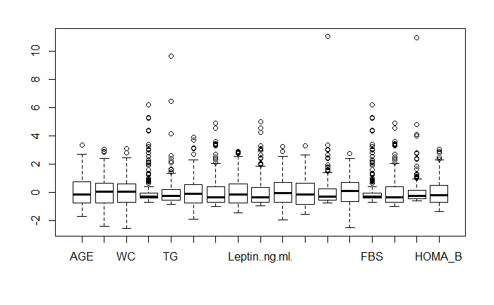

```r
library(foreign)
library(MVN)
mvn(data=datosdf2[,c(2,4,5,6,7,8,12,13,14,15,16,17,18,20,21,22,23)], mvnTest="royston", univariatePlot="box")
```

```r
# Con esta función obtenemos la información estadística básica y un Test Shapiro-Wilk de normalidad de cada una de las variables.
```

**Correlación entre las variables.**

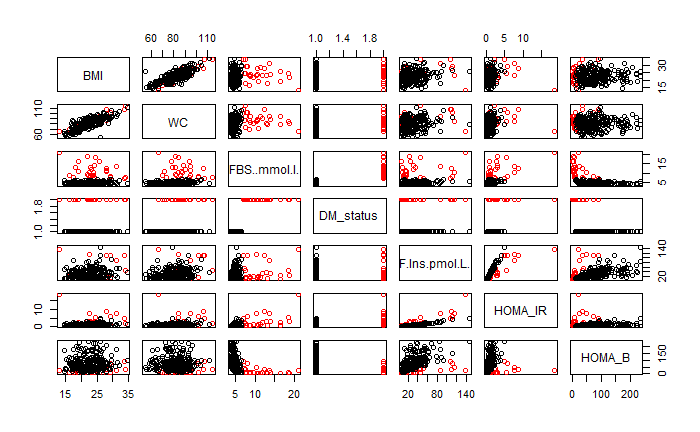

```r
pairs(datosdf2[,c(4,5,6,11,12,22,23)], col=datosdf2$DM_status)
```

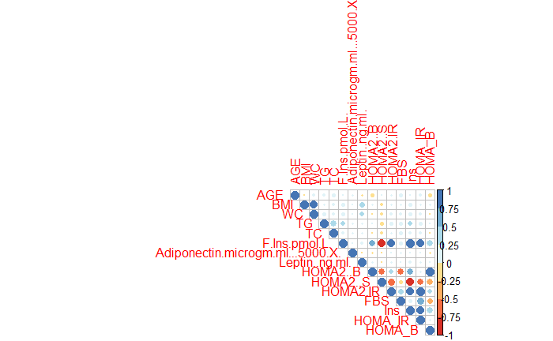

```r
library(corrplot)
library(RColorBrewer)
cordatos<- cor(datosdf2[,-c(1,3,6,9,10,11,18,19)])
corrplot(cordatos,type="upper", col = brewer.pal(n = 8, name = "RdYlBu"))
```

Observamos casos en los que la correlación es alta y por lo tanto aportan información redundante. Se excluirán algunos de estos predictores redundantes en el modelo: HOMA2B, HOMA2S, HOMA2.IR, Ins, FBS.

**Modelo lineal simple.**

Como se puede ver en el gráfico anterior (scatterplot), parece que existe una relación lineal entre el IMC y el perímetro de la cintura(WC):

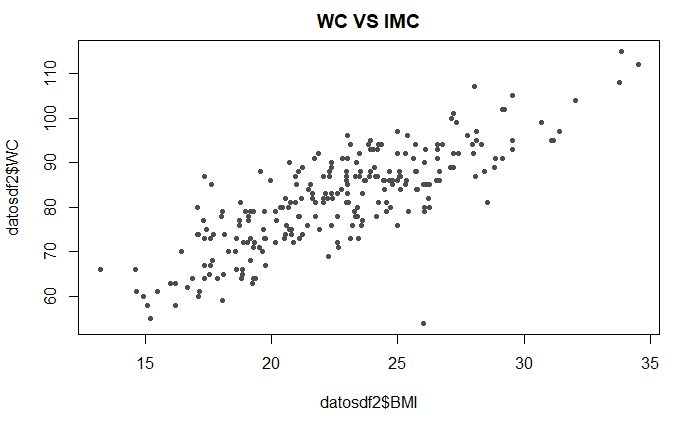

```r
MLS<-lm(data = datosdf2, formula =BMI~WC)
plot(x =datosdf2$BMI, y = datosdf2$WC, main = "WC VS IMC", pch = 20, col = "grey30")
abline(col="red")
```

```r
summary(MLS)
```

```
Call:
lm(formula = BMI ~ WC, data = datosdf2)

Residuals:
   Min     1Q Median     3Q    Max
-6.854 -1.534 -0.183  1.516 11.411

Coefficients:
            Estimate Std. Error t value Pr(>|t|)
(Intercept) -1.05973    1.10972  -0.955    0.341
WC           0.29049    0.01348  21.552   <2e-16 ***
---
Signif. codes:  0 ‘***’ 0.001 ‘**’ 0.01 ‘*’ 0.05 ‘.’ 0.1 ‘ ’ 1

Residual standard error: 2.324 on 251 degrees of freedom
Multiple R-squared:  0.6492,    Adjusted R-squared:  0.6478
F-statistic: 464.5 on 1 and 251 DF,  p-value: < 2.2e-16
```

es decir, según el modelo, si mi cintura mide 65 cm, mi IMC sería:

```r
0.29*65-1.06
```

```
[1] 17.79
```

**Test de Pearson.**

```r
cor.test(datosdf2$BMI, datosdf2$WC, method="pearson")
```

```
    Pearson's product-moment correlation

data:  datosdf2$BMI and datosdf2$WC
t = 21.552, df = 251, p-value < 2.2e-16
alternative hypothesis: true correlation is not equal to 0
95 percent confidence interval:
 0.757689 0.845080
sample estimates:
      cor
0.8057264
```

La correlación es alta.

**Normalidad de los errores**

```r
res<- rstandard(MLS)
par(mfrow=c(1,3))
hist(res)
boxplot(res)
```

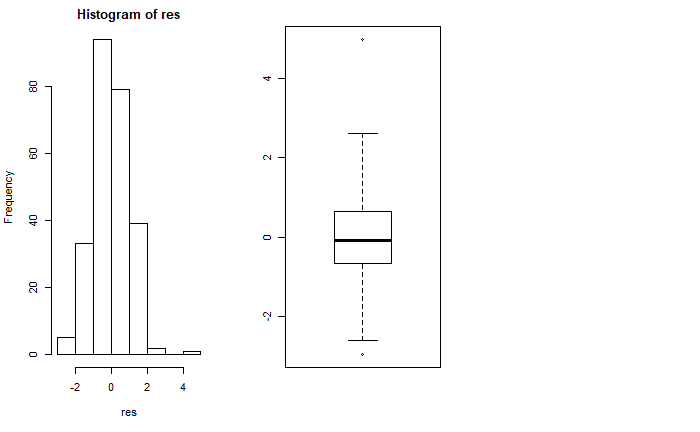

```r
qqnorm(res, pch=19,col = "gray50")
qqline(res)
```

[output not shown]

**Varianza de los errores(heterocedasticidad)**

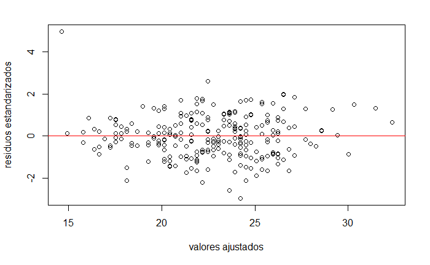

```r
plot(fitted.values(MLS), rstandard(MLS), xlab="valores ajustados", ylab="residuos estandarizados")
abline(h=0, col="red")
```

**Valores atípicos**

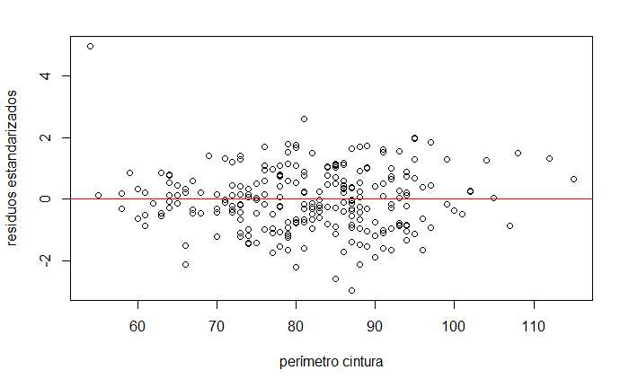

```r
plot(datosdf2$WC, rstandard(MLS),xlab = "perímetro cintura", ylab="residuos estandarizados")
abline(h=0, col="red")
```

Los residuos parecen normales y la varianza es bastante constante. Hay algunos valores que presentan mucha dispersión.

**Modelo lineal múltiple.**

```r
LMC<- lm(HOMA_IR~ BMI + WC + TG+ TC+ FBS..mmol.l.+SBP+DBP+ F.Ins.pmol.L.+HOMA_B+ Adiponectin.microgm.ml...5000.X. +Leptin..ng.ml.+ Body.Fat....from.Age..BMI +DM_status,data = datosdf2)
summary(LMC)
```

```
Call:
lm(formula = HOMA_IR ~ BMI + WC + TG + TC + FBS..mmol.l. + SBP +
    DBP + F.Ins.pmol.L. + HOMA_B + Adiponectin.microgm.ml...5000.X. +
    Leptin..ng.ml. + Body.Fat....from.Age..BMI + DM_status, data = datosdf2)

Residuals:
    Min      1Q  Median      3Q     Max
-2.2645 -0.2722 -0.0112  0.2285  6.8104

Coefficients:
                                   Estimate Std. Error t value Pr(>|t|)
(Intercept)                      -0.9653414  0.4405707  -2.191 0.029409 *
BMI                              -0.0055043  0.0269372  -0.204 0.838263
WC                               -0.0044927  0.0074047  -0.607 0.544601
TG                               -0.0004319  0.0004997  -0.864 0.388311
TC                               -0.0013248  0.0011797  -1.123 0.262561
FBS..mmol.l.                      0.3147131  0.0329641   9.547  < 2e-16 ***
SBP                              -0.0020398  0.0025222  -0.809 0.419485
DBP                               0.0049879  0.0043412   1.149 0.251712
F.Ins.pmol.L.                     0.0533522  0.0024322  21.936  < 2e-16 ***
HOMA_B                           -0.0044100  0.0011229  -3.928 0.000112 ***
Adiponectin.microgm.ml...5000.X. -0.0054536  0.0146218  -0.373 0.709495
Leptin..ng.ml.                    0.0010610  0.0016850   0.630 0.529514
Body.Fat....from.Age..BMI        -0.0091624  0.0094716  -0.967 0.334345
DM_statusNDM                     -0.6421084  0.2419725  -2.654 0.008497 **
---
Signif. codes:  0 ‘***’ 0.001 ‘**’ 0.01 ‘*’ 0.05 ‘.’ 0.1 ‘ ’ 1

Residual standard error: 0.6457 on 239 degrees of freedom
Multiple R-squared:  0.8448,    Adjusted R-squared:  0.8364
F-statistic: 100.1 on 13 and 239 DF,  p-value: < 2.2e-16
```

Por los valores de R-squared, vemos que modelo se ajusta bastante bien.

**(7) ANOVA.**

Utilizamos las variables más significativas para crear un nuevo modelo simplificado:

```r
LMC2<- lm(HOMA_IR~ FBS..mmol.l.+ F.Ins.pmol.L.+HOMA_B+ DM_status,data = datosdf2)
summary(LMC2)
```

```
Call:
lm(formula = HOMA_IR ~ FBS..mmol.l. + F.Ins.pmol.L. + HOMA_B +
    DM_status, data = datosdf2)

Residuals:
    Min      1Q  Median      3Q     Max
-2.3757 -0.2569  0.0133  0.2069  7.3735

Coefficients:
               Estimate Std. Error t value Pr(>|t|)
(Intercept)   -1.806974   0.179937 -10.042   <2e-16 ***
FBS..mmol.l.   0.323636   0.032510   9.955   <2e-16 ***
F.Ins.pmol.L.  0.051332   0.002342  21.916   <2e-16 ***
HOMA_B        -0.004062   0.001108  -3.667   0.0003 ***
DM_statusNDM  -0.760259   0.238272  -3.191   0.0016 **
---
Signif. codes:  0 ‘***’ 0.001 ‘**’ 0.01 ‘*’ 0.05 ‘.’ 0.1 ‘ ’ 1

Residual standard error: 0.6523 on 248 degrees of freedom
Multiple R-squared:  0.8356,    Adjusted R-squared:  0.833
F-statistic: 315.2 on 4 and 248 DF,  p-value: < 2.2e-16
```

```r
anova(LMC, LMC2)
```

```
Analysis of Variance Table

Model 1: HOMA_IR ~ BMI + WC + TG + TC + FBS..mmol.l. + SBP + DBP + F.Ins.pmol.L. +
    HOMA_B + Adiponectin.microgm.ml...5000.X. + Leptin..ng.ml. +
    Body.Fat....from.Age..BMI + DM_status
Model 2: HOMA_IR ~ FBS..mmol.l. + F.Ins.pmol.L. + HOMA_B + DM_status
  Res.Df     RSS Df Sum of Sq     F Pr(>F)
1    239  99.635
2    248 105.533 -9   -5.8981 1.572 0.1243
```

Por los resultados obtenidos en Anova y los valores de R-squared, nos quedamos con este segundo modelo simplificado.

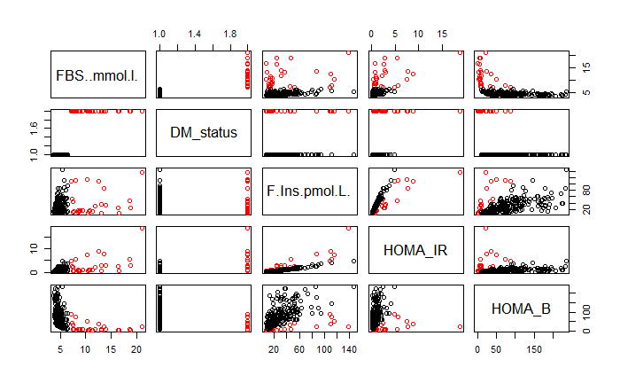

```r
pairs(datosdf2[,c(6,11,12,22,23)], col=datosdf2$DM_status)
```

**Intervalos de confianza para los coeficientes**

```r
confint(LMC2)
```

```
                     2.5 %       97.5 %
(Intercept)   -2.161373403 -1.452575457
FBS..mmol.l.   0.259605436  0.387666427
F.Ins.pmol.L.  0.046718443  0.055944881
HOMA_B        -0.006244309 -0.001880617
DM_statusNDM  -1.229554129 -0.290963696
```

**Diagnosis: normalidad, heterocedasticidad.**

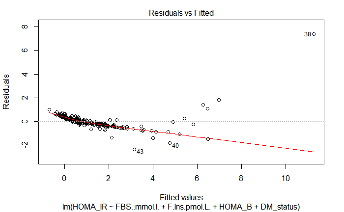

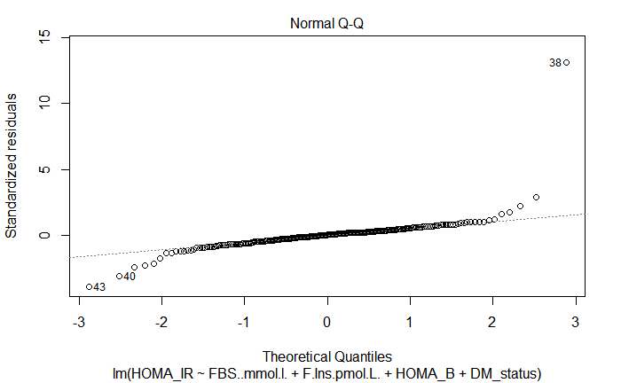

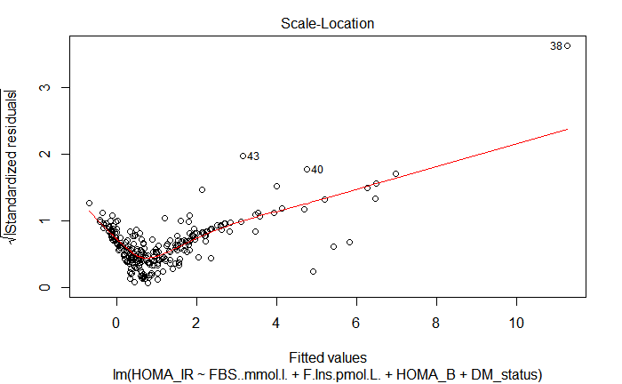

```r
plot(LMC2)
```

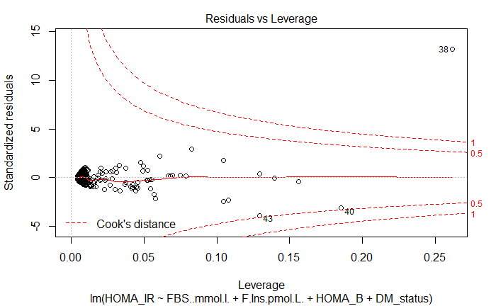

```r
NA
```

Los gráficos primero y tercero se utilizan para contrastar gráficamente la independencia, la homocedasticidad y la linealidad de los residuos. Idealmente, los residuos deben estar aleatoriamente distribuidos a lo largo del gráfico, sin formar ningún tipo de patrón.

El gráfico Q- Q, por su parte, se utiliza para contrastar la normalidad de los residuos. Lo deseable es que los residuos estandarizados estén lo más cerca posible a la línea punteada que aparece en el gráfico.

El gráfico de leverages frente a los residuos estandarizados se utiliza para detectar puntos con una influencia importante en el cálculo de las estimaciones de los parámetros. En caso de detectarse algún punto fuera de los límites que establecen las líneas discontinuas debe estudiarse este punto de forma aislada para detectar, por ejemplo, si la elevada importancia de esa observación se debe a un error.

**Test de normalidad: Shapiro Wilk**

```r
shapiro.test(residuals(LMC2))
```

```
    Shapiro-Wilk normality test

data:  residuals(LMC2)
W = 0.62965, p-value < 2.2e-16
```

Por el valor de p, rechazamos la hipótesis de normalidad de los residuos También podemo realizar el test de Kolmogorov-Smirnov:

```r
ks.test(LMC2$residuals, "pnorm")
```

```
    One-sample Kolmogorov-Smirnov test

data:  LMC2$residuals
D = 0.2365, p-value = 1.022e-12
alternative hypothesis: two-sided
```

Los resultados del test nos confirman lo que se intuía en el gráfico Q-Q: a un 5% de significación los residuos no siguen una distribución normal, puesto que el p-valor que se obtiene es menor que 0.05.

**Heterocedasticidad: Varianza no constante de los residuos.**

Test de puntuación de varianza no constante, y test de Breusch-Pagan:

```r
ncvTest(LMC2)
```

```
Non-constant Variance Score Test
Variance formula: ~ fitted.values
Chisquare = 2170.308, Df = 1, p = < 2.22e-16
```

```r
bptest(LMC2)
```

```
    studentized Breusch-Pagan test

data:  LMC2
BP = 87.007, df = 4, p-value < 2.2e-16
```

**Test de Durbin Watson:**

```r
dwtest(LMC2)
```

```
    Durbin-Watson test

data:  LMC2
DW = 1.3525, p-value = 5.103e-08
alternative hypothesis: true autocorrelation is greater than 0
```

De nuevo, rechazamos la hipótesis de que los residuos son independientes.

Otra manera de comprobarlo: ajustando una recta a los valores absolutos de los residuos (o sus raíces cuadradas) y los valores predichos:

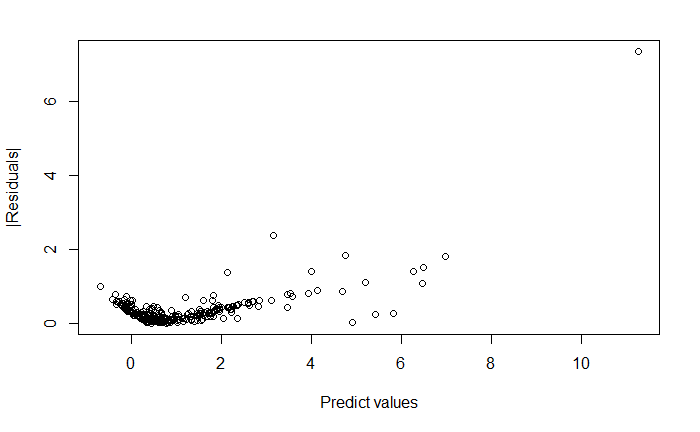

```r
plot(fitted(LMC2),abs(residuals(LMC2)),xlab="Predict values",ylab="|Residuals|")
```

```r
summary(lm(sqrt(abs(residuals(LMC2)))~fitted(LMC2)))
```

```
Call:
lm(formula = sqrt(abs(residuals(LMC2))) ~ fitted(LMC2))

Residuals:
     Min       1Q   Median       3Q      Max
-0.74769 -0.13531 -0.01470  0.09822  1.07273

Coefficients:
             Estimate Std. Error t value Pr(>|t|)
(Intercept)  0.384954   0.018634   20.66   <2e-16 ***
fitted(LMC2) 0.111805   0.009975   11.21   <2e-16 ***
---
Signif. codes:  0 ‘***’ 0.001 ‘**’ 0.01 ‘*’ 0.05 ‘.’ 0.1 ‘ ’ 1

Residual standard error: 0.2311 on 251 degrees of freedom
Multiple R-squared:  0.3335,    Adjusted R-squared:  0.3309
F-statistic: 125.6 on 1 and 251 DF,  p-value: < 2.2e-16
```

** Análisis gráfico autocorrelación de residuos:**

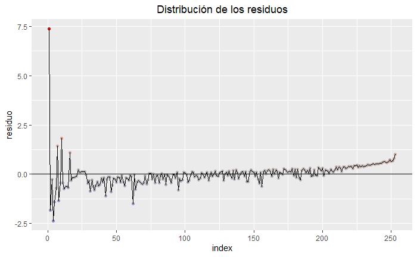

```r
library(ggplot2)
ggplot(data = datosdf2, aes(x = seq_along(LMC2$residuals),
                         y = LMC2$residuals)) +
geom_point(aes(color = LMC2$residuals)) +
scale_color_gradient2(low = "blue3", mid = "grey", high = "red") +
geom_line(size = 0.3) +
labs(title = "Distribución de los residuos", x = "index", y = "residuo")+
geom_hline(yintercept = 0) +
theme(plot.title = element_text(hjust = 0.5), legend.position = "none")
```

**Leverage**

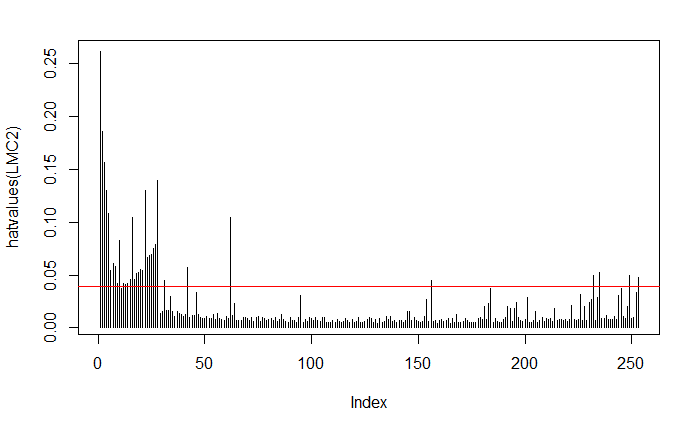

```r
plot(hatvalues(LMC2), type="h")
p<- length(LMC2$coefficients)
n<- length(LMC2$fitted.values)
cutoff<- 2*p/n
abline(h=cutoff, col="red")
```

```r
which(hatvalues(LMC2)>cutoff)
```

```
 38  40  41  43  44  46  47  53  54  58  65  68  71  73  74  78  82  83  85  86  91  98
  1   2   3   4   5   6   7   8   9  10  12  13  14  15  16  17  18  19  20  21  22  23
102 104 107 108 113 122 150 181 332 456 462 477 482
 24  25  26  27  28  31  42  62 156 232 235 249 253
```

```r
head(sort(hatvalues(LMC2), decreasing = T))
```

```
       38        40        41       113        43        91
0.2613593 0.1851367 0.1561394 0.1394024 0.1294910 0.1294337
```

Los valores 38, 40, 41, 113, 43, y 91 son los que tienen un leverage más alto.

**Influencia:**

```r
head(sort(cooks.distance(LMC2), decreasing = T))
```

```
        38         43         40         58        181         44
12.2410527  0.4532648  0.4474035  0.1522983  0.1393824  0.1268850
```

Los valores 38,43 y 40 son los que tienen mayor influencia.

```r
summary(influence.measures(model=LMC2))
```

```
Potentially influential observations of
     lm(formula = HOMA_IR ~ FBS..mmol.l. + F.Ins.pmol.L. + HOMA_B +      DM_status, data = datosdf2) :

    dfb.1_  dfb.FBS. dfb.F.I. dfb.HOMA dfb.DM_N dffit   cov.r   cook.d  hat
38  -9.59_*  9.77_*   4.53_*  -0.98    -7.01_*  14.20_*  0.00_* 12.24_*  0.26_*
40   1.17_* -1.36_*   0.66    -0.55     0.67    -1.52_*  1.02    0.45    0.19_*
41   0.15   -0.17     0.05    -0.05     0.09    -0.19    1.20_*  0.01    0.16_*
43   1.04_* -1.25_*   0.86    -0.63     0.45    -1.55_*  0.85_*  0.45    0.13_*
44   0.55   -0.65     0.34    -0.27     0.24    -0.80_*  1.03    0.13    0.11_*
47  -0.15    0.13     0.27    -0.13     0.05     0.57_*  0.98    0.06    0.06_*
53   0.20   -0.26     0.29    -0.18    -0.06    -0.54_*  0.99    0.06    0.06
58  -0.01   -0.09     0.64    -0.34     0.21     0.89_*  0.94_*  0.15    0.08_*
74   0.17   -0.26     0.48    -0.26     0.29     0.60_*  1.07_*  0.07    0.10_*
78  -0.04    0.04     0.02     0.00    -0.08    -0.11    1.06_*  0.00    0.05
82  -0.03    0.03     0.01     0.00    -0.05    -0.06    1.07_*  0.00    0.05
83  -0.03    0.03     0.01     0.00    -0.05    -0.06    1.08_*  0.00    0.05
85  -0.03    0.03     0.01     0.00    -0.05    -0.05    1.08_*  0.00    0.06
86  -0.02    0.02     0.00     0.00    -0.03    -0.04    1.08_*  0.00    0.05
91   0.07   -0.09     0.10    -0.05     0.10     0.14    1.17_*  0.00    0.13_*
98   0.02   -0.02     0.00     0.00     0.03     0.04    1.09_*  0.00    0.07_*
102  0.03   -0.03     0.00     0.00     0.04     0.05    1.09_*  0.00    0.07_*
104  0.03   -0.03     0.00     0.00     0.05     0.06    1.10_*  0.00    0.07_*
107  0.04   -0.04     0.02    -0.01     0.05     0.06    1.10_*  0.00    0.07_*
108  0.03   -0.04     0.02    -0.01     0.05     0.06    1.11_*  0.00    0.08_*
113 -0.01    0.02    -0.02     0.01    -0.02    -0.02    1.19_*  0.00    0.14_*
150  0.03    0.03    -0.37     0.11     0.06    -0.43_*  1.02    0.04    0.06
181  0.14    0.08    -0.63    -0.01     0.03    -0.84_*  1.01    0.14    0.10_*
456 -0.05    0.03    -0.07     0.14     0.01     0.15    1.06_*  0.00    0.05
462 -0.06    0.03    -0.09     0.16     0.02     0.17    1.07_*  0.01    0.05
```

|  | StudRes | Hat | CookD |
| --- | --- | --- | --- |
| 38 | 23.863726 | 0.2613593 | 12.2410527 |
| 40 | -3.195585 | 0.1851367 | 0.4474035 |
| 43 | -4.020851 | 0.1294910 | 0.4532648 |

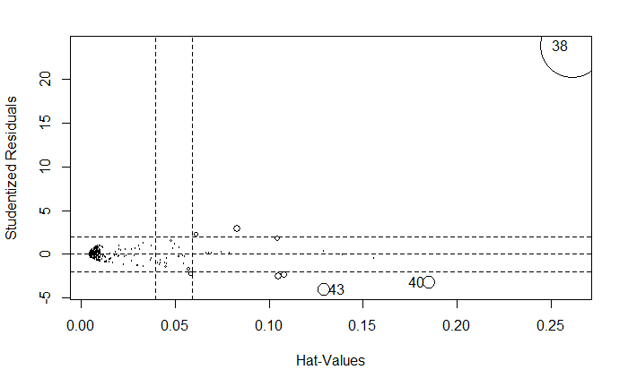

```r
influencePlot(model=LMC2)
```

Algunas observaciones tienen un residuo estandarizado absoluto próximo a 3 (1.73 si se considera la raíz cuadrada) lo que es indicativo de observación atípica. Valores de Leverages (hat) mayores que 2x((p+1)/n), siendo p el número de predictores y n el número de observaciones, o valores de Cook mayores de 1 se consideran influyentes. Todo ello reduce en gran medida la robustez de la estimación del error estándar de los coeficientes de correlación estimados y con ello la del modelo es su conjunto.